# Bar Charts - Python

Matplotlib - Numpy - Seaborn

Renzo Cáceres Rossi

2022/10/03

**Fin Documento**

## Diagramas de Barras

El diagrama de barras (**Bar Chart**) es un gráfico estadístico que nos permite representar la distribución de frecuencias de variables cualitativas y cuantitativas discretas; nuestro objetivo es pasar del lápiz y papel al uso del lenguaje de programación Python 3.9.7(Van Rossum & Drake Jr, 1995), recomendamos la lectura del libro **Python: Los fundamentos del lenguaje**(Chazallet, 2016); compartimos la siguiente imagen como referencia.

[figure not shown]

## Bar Charts - Matplotlib

**Matplotlib**(Hunter, 2007) es una librería del lenguaje de programación Python, que nos permite crear gráficos estadísticos de gran calidad, **RMarkdown**(Allaire et al., 2022) nos permite trabajar con otros lenguajes de programación tales como **C++, SQL, Julia**, entre muchos otros; a continuación mostramos un diagrama de barras (**Bar Chart**) creado con Matplotlib.

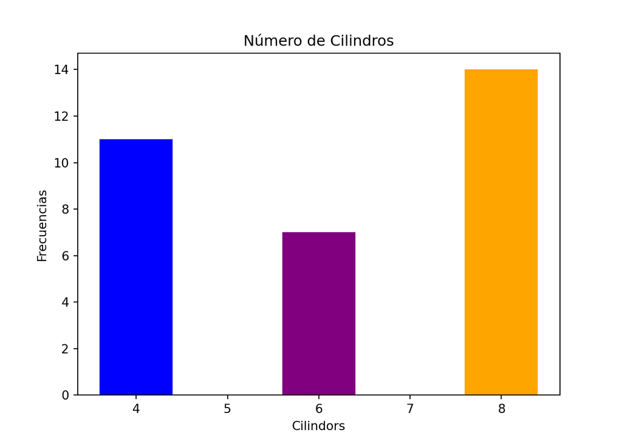

```python
mtcars_data = pd.read_csv("mtcars.csv")

df = pd.DataFrame(mtcars_data)

by_cyl=df.cyl.value_counts()

cyl=by_cyl[:3]

colores = ['orange','blue','purple']

plt.bar(cyl.index,cyl,color=colores)
plt.title("Número de Cilindros")

plt.xlabel("Cilindors")

plt.ylabel("Frecuencias")

plt.show()
```

## Diagrama Barras Horizontal

A continuación, presentamos como crear un **diagrama de barras horizontal** en el lenguaje de programación Python, utilizando la librería Matplotlib.

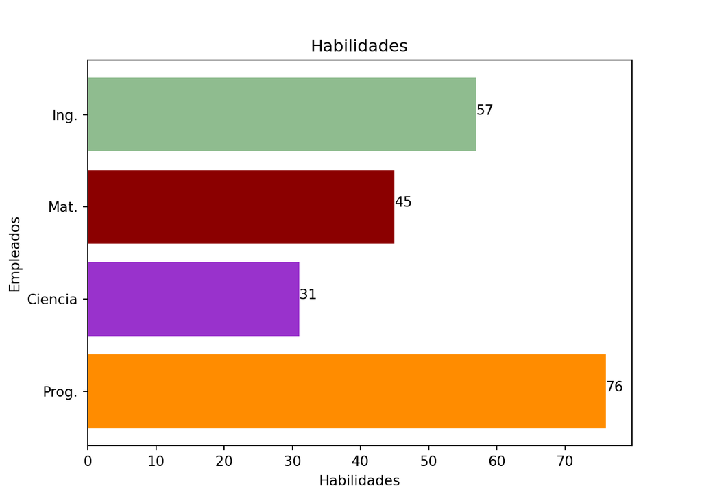

```python
eje_x = ['Prog.', 'Ciencia', 'Mat.', 'Ing.']


eje_y = [76,31,45,57]

colores =['#FF8C00','#9932CC','#8B0000','#8FBC8F']


plt.barh(eje_x, eje_y, color=colores)
for index,value in enumerate(eje_y):
    plt.text(value,index,str(value))

plt.ylabel('Empleados')
plt.xlabel('Habilidades')
plt.title('Habilidades')
plt.show()
```

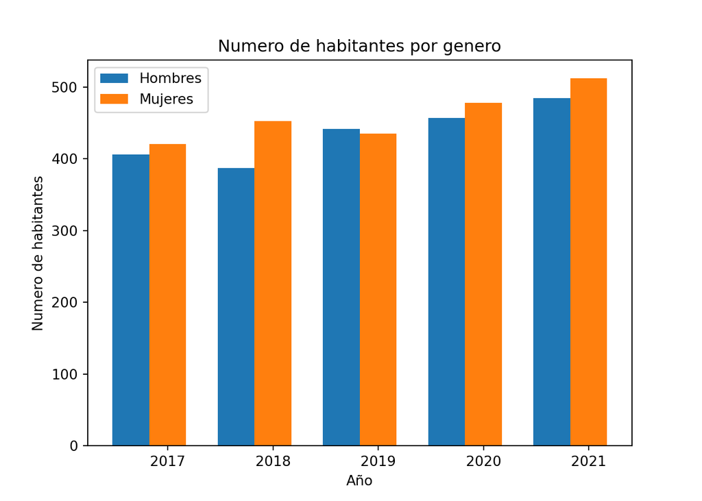

```python
serie_1 = [406, 387, 442, 457, 485]
serie_2 = [421, 453, 435, 478, 512]


numero_de_grupos = len(serie_1)
indice_barras = np.arange(numero_de_grupos)
ancho_barras =0.35

plt.bar(indice_barras, serie_1, width=ancho_barras, label='Hombres')
plt.bar(indice_barras + ancho_barras, serie_2, width=ancho_barras, label='Mujeres')
plt.legend(loc='best')

plt.xticks(indice_barras + ancho_barras, ('2017', '2018', '2019', '2020','2021'))

plt.ylabel('Numero de habitantes')
plt.xlabel('Año')
plt.title('Numero de habitantes por genero')

plt.show()
```

## Bar Charts - Seaborn

**Seaborn**(Waskom et al., 2017) es una librería de Python que nos permite crear gráficos estadísticos de gran calidad, fue creada tomando como base **Matplotlib**.

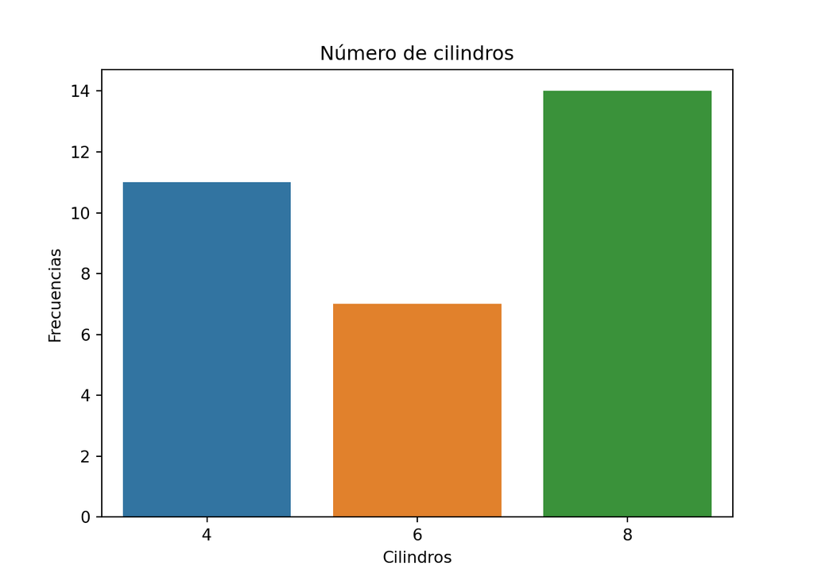

```python
eje_x = [4,6,8]

eje_y = [11,7,14]

sns.barplot(x=eje_x,y=eje_y)

plt.title("Número de cilindros")

plt.xlabel("Cilindros")

plt.ylabel("Frecuencias")

plt.show()
```

## YouTube - Tutorial

Compartimos el siguiente tutorial tomado de la plataforma **YouTube** que muestra como crear diagramas de barras (**Bar Charts**) en el lenguaje de programación Python, utilizando las librerías **Matplotlib** y **Seaborn**.

[video not shown]

**Inicio Documento**

## Referencias Bibliográficas

Allaire, J., Xie, Y., McPherson, J., Luraschi, J., Ushey, K., Atkins, A., Wickham, H., Cheng, J., Chang, W., & Iannone, R. (2022). *Rmarkdown: Dynamic documents for r*. https://github.com/rstudio/rmarkdown

Chazallet, S. (2016). *Python 3: Los fundamentos del lenguaje*. Ediciones ENI.

Harris, C. R., Millman, K. J., Walt, S. J. van der, Gommers, R., Virtanen, P., Cournapeau, D., Wieser, E., Taylor, J., Berg, S., Smith, N. J., Kern, R., Picus, M., Hoyer, S., Kerkwijk, M. H. van, Brett, M., Haldane, A., Río, J. F. del, Wiebe, M., Peterson, P., … Oliphant, T. E. (2020). Array programming with NumPy. *Nature*, *585*(7825), 357–362. https://doi.org/10.1038/s41586-020-2649-2

Hunter, J. D. (2007). Matplotlib: A 2D graphics environment. *Computing in Science & Engineering*, *9*(3), 90–95. https://doi.org/10.1109/MCSE.2007.55

Van Rossum, G., & Drake Jr, F. L. (1995). *Python reference manual*. Centrum voor Wiskunde en Informatica Amsterdam.

Waskom, M., Botvinnik, O., O’Kane, D., Hobson, P., Lukauskas, S., Gemperline, D. C., Augspurger, T., Halchenko, Y., Cole, J. B., Warmenhoven, J., Ruiter, J. de, Pye, C., Hoyer, S., Vanderplas, J., Villalba, S., Kunter, G., Quintero, E., Bachant, P., Martin, M., … Qalieh, A. (2017). *Mwaskom/seaborn: v0.8.1 (september 2017)* (Version v0.8.1) [Computer software]. Zenodo. https://doi.org/10.5281/zenodo.883859